# mathanalysis_standardcalc209-215

```python
%%html
<style>
@import url('https://fonts.googleapis.com/css?family=Roboto&effect=3d|brick-sign|');
span {font-family:Roboto; color:black; text-shadow:4px 4px 4px #aaa;}
h1,h2 {font-family:Roboto; color:slategray; text-shadow:4px 4px 4px #aaa;}
div.output_subarea, div.output_area pre{font-family:Roboto; font_size:120%; color:darkblue;}
</style>
```

```python
import math, sympy, numpy
from sympy import *
sympy.init_printing(use_unicode=True)
import pylab as plt
%matplotlib inline
```

[GeoGebra](https://www.geogebra.org/graphing?lang=en)

LaTeX/Mathematics

[SymPy Modules Reference. Calculus](https://docs.sympy.org/latest/modules/calculus/index.html)

[Sympy : Symbolic Mathematics in Python](https://www.scipy-lectures.org/advanced/sympy.html)

[Math24.ru. Ряды Тейлора и Маклорена](http://www.math24.ru/%D1%80%D1%8F%D0%B4%D1%8B-%D1%82%D0%B5%D0%B9%D0%BB%D0%BE%D1%80%D0%B0-%D0%B8-%D0%BC%D0%B0%D0%BA%D0%BB%D0%BE%D1%80%D0%B5%D0%BD%D0%B0.html)

[Math24.ru. Бесконечно малые функции](http://www.math24.ru/%D0%B1%D0%B5%D1%81%D0%BA%D0%BE%D0%BD%D0%B5%D1%87%D0%BD%D0%BE-%D0%BC%D0%B0%D0%BB%D1%8B%D0%B5-%D1%84%D1%83%D0%BD%D0%BA%D1%86%D0%B8%D0%B8.html)

# Вариант 22

# Дифференцирование и приложения

## Типовой расчет №9

Найти производную $n$-ого порядка.

$\large{\displaystyle{y = \frac{2x - 4}{8x + 3} }}$

## Решение

$\large{\displaystyle{y ' = \Bigg(\frac{2x - 4}{8x + 3}\Bigg) ' = \frac{(2x - 4) ' (8x + 3) - (2x - 4) (8x + 3) '}{(8x + 3)^2} = }}$

$\large{\displaystyle{ = \frac{2 (8x + 3) - 8(2x - 4)}{(8x + 3)^2} = \frac{16x + 6 - 16x + 32}{(8x + 3)^2} = 38 * (8x + 3)^{-2} }}$

$\large{\displaystyle{y '' = \Bigg(38 * (8x + 3)^{-2} \Bigg) ' = 38 * (-2) * 8 * (8x + 3)^{-3} }}$

$\large{\displaystyle{y ''' = \Bigg(38 * (-2) * 8 * (8x + 3)^{-3} \Bigg) ' = 38 * 6 * 8^2 * (8x + 3)^{-4} }}$

$...$

$\large{\displaystyle{y ^{(n)} = 38 * (-1)^{n-1} * n! * 8^{n - 1} *(8x + 3)^{-n - 1} }}$

## Ответ

$\large{\displaystyle{y ^{(n)} = 38 * (-1)^{n-1} * n! * 8^{n - 1} *(8x + 3)^{-n - 1} }}$

```python
x = Symbol('x')
y = (2 * x - 4) / (8 * x + 3)
```

```python
diff(y, x), diff(diff(y, x), x), diff(diff(diff(y, x), x), x)
```

$$\left ( - \frac{8 \left(2 x - 4\right)}{\left(8 x + 3\right)^{2}} + \frac{2}{8 x + 3}, \quad \frac{128 \left(2 x - 4\right)}{\left(8 x + 3\right)^{3}} - \frac{32}{\left(8 x + 3\right)^{2}}, \quad - \frac{3072 \left(2 x - 4\right)}{\left(8 x + 3\right)^{4}} + \frac{768}{\left(8 x + 3\right)^{3}}\right )$$

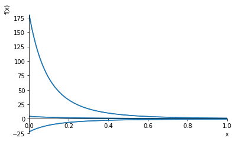

```python
plot(diff(y, x), 38 * (8 * x + 3) ** (-2),
     diff(diff(y, x), x), 38 * (-2) * 8 * (8 * x + 3) ** (-3),
     diff(diff(diff(y, x), x), x), 38 * 6 * 8 ** 2 * (8 * x + 3) ** (-4),
     (x,0,1));
```

## Типовой расчет №10

Вычислить предел функции.

$\large{\displaystyle{ \lim_{ x \to 0} \frac{4 \ tg \ 3 x - 3 \ tg \ 4x}{7x - sin \ 7x} }}$

## Решение

Числитель и знаменатель дроби стремятся к 0 при $x \to 0$,

значит дробь является неопределенным выражением вида $\big[\frac{0}{0}\big]$ при $x \to 0$.

Заменить знаменатель на эквивалентную бесконечно малую функцию нельзя, поскольку:

$7x - sin \ 7x = 7x - 7x - \overline{o}(7x) = - \overline{o}(7x)$ при $x \to 0$.

То же самое верно и в отношении числителя.

Для раскрытия неопределенности $\big[\frac{0}{0}\big]$ при $x \to 0$ преобразуем функцию,

используя разложение в ряды Маклорена:

$\large{\displaystyle{ tg \ 3x = 3x + \frac{(3x)^3}{3} + \overline{o_1(x^3)} }}$

$\large{\displaystyle{ tg \ 4x = 4x + \frac{(4x)^3}{3} + \overline{o_2(x^3)} }}$

$\large{\displaystyle{sin \ 7x = 7x - \frac{(7x)^3}{3!} + \overline{o_3(x^3)} }}$

$\large{\displaystyle{ 4 \ tg \ 3x - 3 \ tg\ 4x = 12 x + 36 x^3 + 4 \overline{o_1(x^3)} - 12 x - 64 x^3 - 3 \overline{o_2(x^3)} = }}$

$\large{\displaystyle{ = -28x^3 + 4 \overline{o_1(x^3)} - 3 \overline{o_2(x^3)} }}$

$\large{\displaystyle{7x - sin \ 7x = 7x - 7x + \frac{(7x)^3}{3!} - \overline{o_3(x^3)} = \frac{343}{6} x^3 - \overline{o_3(x^3)} }}$

Учитывая, что $4 \overline{o_1(x^3)} - 3 \overline{o_2(x^3)}, \overline{o_3(x^3)}$ - бесконечно малые величины более высокого порядка, чем $x^3$:

$\large{\displaystyle{ \lim_{ x \to 0} \frac{4 \ tg \ 3 x - 3 \ tg \ 4x}{7x - sin \ 7x} = \lim_{ x \to 0} \frac{-28 x^3}{343 x^3 / 6 } = -\frac{24}{49} }}$

## Ответ

$\large{\displaystyle{ \lim_{ x \to 0} \frac{4 \ tg \ 3 x - 3 \ tg \ 4x}{7x - sin \ 7x} = -\frac{24}{49} }}$

```python
x = Symbol('x')
y = (4 * tan(3 * x) - 3 * tan(4 * x)) / (7 * x - sin (7 * x))
```

```python
limit(y, x, 0)
```

$$- \frac{24}{49}$$

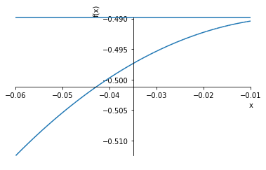

```python
plot(y, -24/49, (x, -0.06, -0.01));
```

## Типовой расчет №11

Вычислить предел функции.

$\large{\displaystyle{ \lim_{ x \to -1} \frac{x^4 + x^3 - 3x^2 - 5x - 2}{x^4 + 2x^3 - 2x - 1} }}$

## Решение

Числитель и знаменатель дроби стремятся к 0 при $x \to 0$,

значит дробь является неопределенным выражением вида $\big[\frac{0}{0}\big]$ при $x \to 0$.

### I Способ

Заменим переменную $t = x + 1, x \to -1 \implies x = t - 1, t \to 0$.

$\large{\displaystyle{ \lim_{ x \to -1} \frac{x^4 + x^3 - 3 x^2 - 5 x - 2}{x^4 + 2 x^3 - 2 x - 1} = \lim_{ t \to 0} \frac{(t - 1)^4 + (t - 1)^3 - 3 (t - 1)^2 - 5(t - 1) - 2}{(t - 1)^4 + 2 (t - 1)^3 - 2 (t - 1) - 1} = }}$

$\large{\displaystyle{ = \lim_{ t \to 0} \frac{t^4 - 4 t^3 + 6 t^2 - 4 t + 1 + t^3 - 3 t^2 + 3t - 1 - 3 (t^2 - 2 t + 1) - 5 t + 3}{t^4 - 4 t^3 + 6 t^2 - 4 t + 1 + 2 (t^3 - 3 t^2 + 3t - 1) - 2 t + 1} = }}$

$\large{\displaystyle{ = \lim_{ t \to 0} \frac{t^4 - 3 t^3}{t^4 - 2 t^3} = \lim_{ t \to 0} \frac{t - 3}{t - 2} = \frac{-3}{-2} = 1.5}}$

### II Способ

Разложим на множители числитель и знаменатель дроби

и поделим несколько раз на $x + 1 \neq 0$ при $ x \to - 1$:

$\large{\displaystyle{ = \lim_{ x \to -1} \frac{x^2 - x - 2}{x^2 - 1} = \lim_{ x \to -1} \frac{(x + 1)(x - 2)}{(x + 1)(x - 1)} = }}$

$\large{\displaystyle{ = \lim_{ x \to -1} \frac{x - 2}{x - 1} = \frac{-1 - 2}{-1 - 1} = 1.5}}$

## Ответ

$\large{\displaystyle{ \lim_{ x \to -1} \frac{x^4 + x^3 - 3x^2 - 5x - 2}{x^4 + 2x^3 - 2x - 1} = 1.5}}$

```python
t = Symbol('t')
expand((t - 1)**4 + (t - 1)**3 - 3 * (t - 1)**2 - 5 * (t - 1) - 2), expand((t - 1)**4 + 2 * (t - 1)**3 - 2 * (t - 1) - 1)
```

$$\left ( t^{4} - 3 t^{3}, \quad t^{4} - 2 t^{3}\right )$$

```python
limit((t ** 4 - 3 * t ** 3)/( t** 4 - 2 * t ** 3), t, 0)
```

$$\frac{3}{2}$$

```python
x = Symbol('x')
y = (x ** 4 + x ** 3 - 3 * x ** 2 - 5 * x - 2) / (x ** 4 + 2 * x ** 3 - 2 * x - 1)
```

```python
factor(x ** 4 + x ** 3 - 3 * x ** 2 - 5 * x - 2), factor(x ** 4 + 2 * x ** 3 - 2 * x - 1)
```

$$\left ( \left(x - 2\right) \left(x + 1\right)^{3}, \quad \left(x - 1\right) \left(x + 1\right)^{3}\right )$$

```python
simplify((x ** 4 + x ** 3 - 3 * x ** 2 - 5 * x - 2) / (x + 1)), simplify((x ** 4 + 2 * x ** 3 - 2 * x - 1) / (x + 1))
```

$$\left ( x^{3} - 3 x - 2, \quad x^{3} + x^{2} - x - 1\right )$$

```python
simplify((x ** 3 - 3 * x - 2) / (x + 1)), simplify((x ** 3 +  x ** 2 - x - 1) / (x + 1))
```

$$\left ( x^{2} - x - 2, \quad x^{2} - 1\right )$$

```python
limit(y, x, -1)
```

$$\frac{3}{2}$$

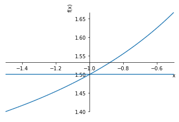

```python
plot(y, 1.5, (x, -1.5, -0.5));
```

## Типовой расчет №12

Составить уравнение нормали и касательной к кривой, заданной параметрически,

в точке, соответствующей значению параметра $t_0$.

$\large{\displaystyle{\begin {cases} x = \ln tg \ t, \\ y = \frac{1}{sin^2 t}, \end {cases}, \ t_0 = \frac{\pi}{4} }}$

## Решение

Уравнение касательной в точке $x_0$:

$\large{\displaystyle{y - f(x_0) = f'(x_0)(x - x_0)}}$.

Уравнение нормали в точке $x_0$:

$\large{\displaystyle{y - f(x_0) = -\frac{1}{f'(x_0)}(x - x_0)}}$.

$\large{\displaystyle{ x_0 = \ln tg \ t_0 = \ln tg \bigg(\frac{\pi}{4}\bigg) = 0 }}$

$\large{\displaystyle{ f(x_0) = y_0 = \frac{1}{sin^2 t_0} = \frac{1}{sin^2 \frac{\pi}{4}} = \frac{1}{(\sqrt{2}/2)^2} = 2 }}$

$\large{\displaystyle{ f ' (x) = \frac{y ' (t)}{x ' (t)} = \frac{\big(\frac{1}{sin^2 t}\big) '}{(\ln tg \ t) ' } = \frac{-\frac{2 \ cos \ t}{sin^3 t} }{\frac{1}{tg \ t \ cos^2 t}} = }}$

$\large{\displaystyle{= \frac{-2 \ cos^3 \ t \ tg \ t}{sin^3 t} = -2 \ ctg^2 t}}$

$\large{\displaystyle{ f ' (x_0) = \frac{y ' (t_0)}{x ' (t_0)} = -2 \ ctg^2(t_0) = -2 \ ctg^2 \bigg(\frac{\pi}{4}\bigg) = -2}}$

Уравнение касательной в точке $x_0$:

$\large{\displaystyle{y - 2 = -2 \ (x - 0) \iff y = -2 \ x + 2}}$.

Уравнение нормали в точке $x_0$:

$\large{\displaystyle{y - 2 = -\frac{1}{-2}(x - 0) \iff y = 0.5 \ x + 2}}$.

## Ответ

Уравнение касательной в точке $t_0 = \frac{\pi}{4}: y = -2x + 2$.

Уравнение нормали в точке $t_0 = \frac{\pi}{4}: y = 0.5x + 2$.

```python
t = Symbol('t')
x = log(tan(t))
y = 1 / sin(t) ** 2
```

```python
x.evalf(subs={t:pi/4}), y.evalf(subs={t:pi/4})
```

$$\left ( 0, \quad 2.0\right )$$

```python
diff(x, t), diff(y, t)
```

$$\left ( \frac{\tan^{2}{\left (t \right )} + 1}{\tan{\left (t \right )}}, \quad - \frac{2 \cos{\left (t \right )}}{\sin^{3}{\left (t \right )}}\right )$$

```python
diff(y, t).evalf(subs={t:pi/4}) / diff(x, t).evalf(subs={t:pi/4})
```

$$-2.0$$

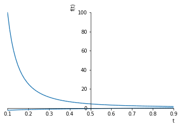

```python
plot(x,y, (t, 0.1,0.9));
```

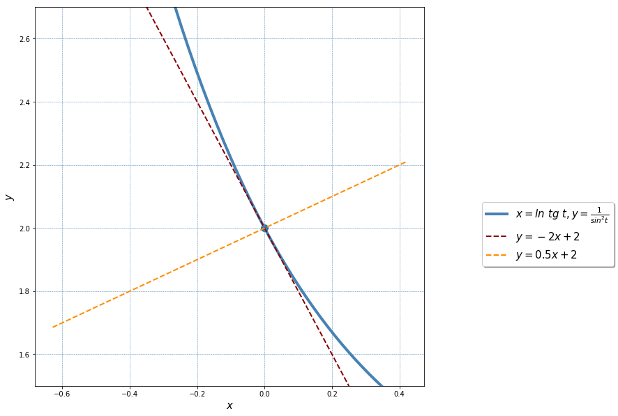

```python
t = numpy.linspace(0.49, 0.99)

x =  lambda k: numpy.log(numpy.tan(k))
y = lambda k: 1 / numpy.sin(k) ** 2

plt.figure(figsize=(10,10)) ; plt.grid(c='steelblue',ls='--',lw=0.5)
plt.plot(x(t), y(t), c='steelblue', lw=4, label=r'$x = ln \ tg \ t, y = \frac{1}{sin^2 t}$')
plt.plot(x(t), -2 * x(t) + 2, c='darkred',ls='--',lw=2, label=r'$y = -2x + 2$')
plt.plot(x(t), 0.5 * x(t) + 2, c='darkorange',ls='--',lw=2, label=r'$y = 0.5x + 2$')
plt.scatter(0,2, s=100)

plt.xlabel(r'$x$', fontsize=15); plt.ylabel(r'$y$', fontsize=15); plt.ylim(1.5, 2.7)
plt.legend(fontsize=15, shadow=True, bbox_to_anchor=(1.5,0.5));
```

## Типовой расчет №13

Найти наибольшее и наименьшее значения функции на заданном отрезке.

$\large{\displaystyle{ y = \frac{x - 1}{1 + x}, \ x \in \big[0; 4\big] }}$

## Решение

Областью определения данной функции является объединение интервалов $(-\infty; -1) \cup (-1; +\infty)$.

Значит, на отрезке $\big[0; 4\big]$ она непрерывна и достигает наименьшего и наибольшего значений.

Точки, в которых функция достигает на отрезке этих значений, являются

- или точками локального экстремума, принадлежащими этому интервалу,
- или концами отрезка.

В точках локального экстремума производная функции равна нулю или не существует.

$\large{\displaystyle{ y ' = \bigg(\frac{x - 1}{1 + x}\bigg) ' = \frac{(x - 1)' \ ( x + 1) - (x - 1) \ ( x+ 1)'}{(x + 1)^2} = \frac{2}{(x + 1)^2} }}$

$\large{\displaystyle{\forall x \in \big[0; 4\big]: \exists y ' (x) \land y ' (x) \neq 0}}$.

На заданном интервале функция локальных экстремумов не имеет.

Вычислим значение функции на концах отрезка.

$y(0) = (0 - 1) / (0 + 1) = -1$ - наименьшее значение.

$y(4) = (4 - 1) / (4 + 1) = 0.6$ - наибольшее.

## Ответ:

$\large{\displaystyle{ \max_{ x \in [0; 4]} \frac{x - 1}{1 + x} = 0.6 }}$

$\large{\displaystyle{ \min_{ x \in [0; 4]} \frac{x - 1}{1 + x} = -1 }}$

```python
x = Symbol('x')
y = (x - 1) / (1 + x)
```

```python
diff(y, x), diff(diff(y, x), x)
```

$$\left ( - \frac{x - 1}{\left(x + 1\right)^{2}} + \frac{1}{x + 1}, \quad \frac{2 \left(x - 1\right)}{\left(x + 1\right)^{3}} - \frac{2}{\left(x + 1\right)^{2}}\right )$$

```python
simplify(diff(y, x)), simplify(diff(diff(y, x), x))
```

$$\left ( \frac{2}{\left(x + 1\right)^{2}}, \quad - \frac{4}{\left(x + 1\right)^{3}}\right )$$

```python
solve(diff(y, x), 0)
```

$$\left [ \right ]$$

```python
y.evalf(subs={x:0}), y.evalf(subs={x:4})
```

$$\left ( -1.0, \quad 0.6\right )$$

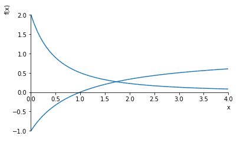

```python
plot(y, diff(y, x), (x, 0, 4));
```

## Типовой расчет №14

Провести полное исследование функции и построить ее график.

$\large{\displaystyle{ y = \frac{4}{x^2 + 2 x - 3} }}$

```python
x = Symbol('x')
y = 4 / (x ** 2 + 2 * x - 3)
```

## Решение

1) Найдем область определения функции и точки разрыва.

$\large{\displaystyle{ y = \frac{4}{x^2 + 2 x - 3} = \frac{4}{(x - 1) \ (x + 3)} }}$

$\large{\displaystyle{ D(y)= (-\infty; -3) \cup (-3; 1) \cup (1; +\infty) }}$

$\large{\displaystyle{ x = -3; x = 1 }}$ - точки разрыва.

2) Вычислим односторонние пределы функции

- в граничных точках области определения,
- в точках разрыва.

Найдем вертикальные асимптоты.

$\large{\displaystyle{ \lim_{ x \to +\infty} \frac{4}{x^2 + 2 x - 3} = \lim_{ x \to +\infty} \frac{4}{x^2} = 0}}$

$\large{\displaystyle{ \lim_{ x \to -\infty} \frac{4}{x^2 + 2 x - 3} = \lim_{ x \to -\infty} \frac{4}{x^2} = 0}}$

$\large{\displaystyle{ \lim_{ x \to -3+0} \frac{4}{x^2 + 2 x - 3} = \frac{4}{(-3 + 0 - 1) \ (-3 + 0 + 3)} = \frac{4}{+ 0 \ (-4 + 0)} = -\infty }}$

$\large{\displaystyle{ \lim_{ x \to -3-0} \frac{4}{x^2 + 2 x - 3} = \frac{4}{(-3 - 0 - 1) \ (-3 - 0 + 3)} = \frac{4}{- 0 \ (-4 - 0)} = +\infty}}$

$\large{\displaystyle{ \lim_{ x \to 1+0} \frac{4}{x^2 + 2 x - 3} = \frac{4}{(1 + 0 - 1) \ (1+ 0 + 3)} = \frac{4}{+ 0 \ (4 + 0)} = +\infty}}$

$\large{\displaystyle{ \lim_{ x \to 1-0} \frac{4}{x^2 + 2 x - 3} = \frac{4}{(1 - 0 - 1) \ (1- 0 + 3)} = \frac{4}{- 0 \ (4 - 0)} = -\infty}}$

Прямые $x = -3, \ x = 1$ являются вертикальными асимптотами.

```python
factor(x ** 2 + 2 * x - 3)
```

$$\left(x - 1\right) \left(x + 3\right)$$

```python
limit(4 / (x ** 2 + 2 * x - 3), x, -oo), limit(4 / (x ** 2 + 2 * x - 3), x, +oo)
```

$$\left ( 0, \quad 0\right )$$

```python
limit(4 / (x ** 2 + 2 * x - 3), x, -3, '+'), limit(4 / (x ** 2 + 2 * x - 3), x, -3, '-')
```

$$\left ( -\infty, \quad \infty\right )$$

```python
limit(4 / (x ** 2 + 2 * x - 3), x, 1, '+'), limit(4 / (x ** 2 + 2 * x - 3), x, 1, '-')
```

$$\left ( \infty, \quad -\infty\right )$$

3) Проверим, является ли функция четной, нечетной, периодической.

$\large{\displaystyle{y(-x) = \frac{4}{(-x)^2 + 2 (-x) - 3} = \frac{4}{x^2 - 2x - 3} \implies y(-x) \neq y(x) \land y(-x) \neq -y(x) }}$

Функция не является четной или нечетной.

Обозначим $ t \neq 0$ предполагаемый период функции.

$\large{\displaystyle{y(x + t) = y(x) \iff \frac{4}{(x + t)^2 + 2 (x + t) - 3} = \frac{4}{x^2 + 2x - 3} \iff }}$

$\large{\displaystyle{\iff (x + t)^2 + 2 (x + t) = x^2 + 2x \iff 2 x t + t^2 + 2 t= 0 \iff}}$

$\large{\displaystyle{ \iff t \ (t + 2 x + 2) = 0 \iff t = 0 \lor t = -2x - 2}}$

$\large{\displaystyle{ t \neq const \land t = t(x) }}$

Функция не является периодической.

4) Найдем точки пересечения графика функции с осями координат.

$\large{\displaystyle{x = 0 \implies y = \frac{4}{0 ^2+ 2 * 0 - 3} \approx -1.33 }}$

$\large{\displaystyle{\forall x \in \mathbb{R}: y(x) \neq 0}}$

График функции пересекает ось $Oy$ в точке $(0; -1\frac{1}{3})$ и не пересекает ось $Ox$.

```python
4 / (x ** 2 + 2 * x - 3) == 4 / ((-x )** 2 + 2 * (-x) - 3)
```

```
False
```

```python
-4 / (x ** 2 + 2 * x - 3) == 4 / ((-x )** 2 + 2 * (-x) - 3)
```

```
False
```

```python
y.evalf(subs={x:0})
```

$$-1.33333333333333$$

```python
solve(4 / (x ** 2 + 2 * x - 3), 0)
```

$$\left [ \right ]$$

5) Найдем наклонные асимпоты графика функции.

Вычислим коэффициенты для прямой $y = kx + b$, являющейся наклонной асимптотой.

$\large{\displaystyle{k = \lim_{ x \to +\infty} \frac{\frac{4}{x^2 + 2 x - 3}}{x} = \lim_{ x \to +\infty} \frac{4}{x^3 + 2x^2 - 3 x} = 0}}$

$\large{\displaystyle{k= \lim_{ x \to -\infty} \frac{\frac{4}{x^2 + 2 x - 3}}{x} = \lim_{ x \to -\infty} \frac{4}{x^3 + 2x^2 - 3 x} = 0}}$

$\large{\displaystyle{b = \lim_{ x \to +\infty} \frac{4}{x^2 + 2 x - 3} - kx = \lim_{ x \to +\infty} \frac{4}{x^2 + 2 x - 3} - 0= 0}}$

$\large{\displaystyle{b = \lim_{ x \to -\infty} \frac{4}{x^2 + 2 x - 3} - kx = \lim_{ x \to -\infty} \frac{4}{x^2 + 2 x - 3} - 0= 0}}$

$y = 0$ - уравнение наклонной асимптоты.

6) Вычислим первую производную. Найдем точки локального экстремума и промежутки монотонности.

$\large{\displaystyle{ y ' = \bigg(\frac{4}{x^2 + 2 x - 3}\bigg) ' = \frac{(4)' \ (x^2 + 2 x - 3) - 4 \ (x^2 + 2 x - 3)'}{(x^2 + 2 x - 3)^2} = }}$

$\large{\displaystyle{= \frac{0 \ (x^2 + 2 x - 3) - 4 \ (2 x + 2 x)}{(x^2 + 2 x - 3)^2} = \frac{ - 8 \ (x + 1)}{(x + 3)^2 (x - 1)^2} }}$

Функция может иметь локальный экстремум в критических точках, если:

- функция определена и непрерывна в этих точках,
- значение производной в них равно нулю или не существует.

В данном случае производная функции определена на всей $ D(y)= (-\infty; -3) \cup (-3; 1) \cup (1; +\infty)$,

поэтому нужно найти только стационарные точки $x$, для которых $y ' (x) = 0$

$\large{\displaystyle{ \frac{ - 8 \ (x + 1)}{(x + 3)^2 (x - 1)^2} = 0 \iff x = -1 }}$

Промежутки монотонности:

| $x$ | $(-\infty; -3)$ | $-3$ | $(-3; -1)$ | $ -1$ | $(-1; 1)$ | $1$ | $(1; +\infty)$ |
| --- | --- | --- | --- | --- | --- | --- | --- |
| $y ' (x)$ | $+$ | $\nexists$ | $+$ | $0$ | $-$ | $\nexists$ | $-$ |
| $y (x)$ | $\nearrow$ | $\nexists$ | $\nearrow$ | $-1$ | $\searrow$ | $\nexists$ | $\searrow$ |

$x = -1$ является точкой локального максимума, $y ( -1 ) = -1$.

$x = -3$, $x = 1$ не являются точками локального экстремума.

$(-\infty; -3), \ (-3; -1)$ - функция возрастает.

$(-1; 1), \ (1; +\infty)$ - функция убывает.

```python
limit(y / x, x, oo, '+'), limit(y / x, x, oo, '-')
```

$$\left ( 0, \quad 0\right )$$

```python
limit(y - 0 *x, x, oo, '+'), limit(y - 0 * x, x, oo, '-')
```

$$\left ( 0, \quad 0\right )$$

```python
simplify(diff(y, x))
```

$$- \frac{8 x + 8}{\left(x^{2} + 2 x - 3\right)^{2}}$$

```python
solve(diff(y, x), x)
```

$$\left [ -1\right ]$$

```python
y.evalf(subs={x:-1})
```

$$-1.0$$

```python
solve(diff(y, x) > 0, x), solve(diff(y, x) < 0, x)
```

$$\left ( \left(-\infty < x \wedge x < -3\right) \vee \left(-3 < x \wedge x < -1\right), \quad \left(-1 < x \wedge x < 1\right) \vee \left(1 < x \wedge x < \infty\right)\right )$$

7) Вычислим вторую производную. Найдем точки перегиба графика функции и промежутки выпуклости.

$\large{\displaystyle{y '' = \Bigg(\frac{ - 8 \ (x + 1)}{(x^2 + 2 x - 3)^2}\Bigg)' = }}$

$\large{\displaystyle{= -8 * \frac{(x + 1)' \ (x^2 + 2 x - 3)^2 - (x + 1) \ ((x^2 + 2 x - 3)^2)'}{(x^2 + 2 x - 3)^4} = }}$

$\large{\displaystyle{= -8 * \frac{(x^2 + 2 x - 3)^2 - 2 \ (x + 1) \ (x^2 + 2 x - 3) \ (2x + 2)}{(x^2 + 2 x - 3)^4} = }}$

$\large{\displaystyle{= -8 * \frac{x^2 + 2 x - 3 - 2 \ (2x^2 + 4 x + 2)}{(x^2 + 2 x - 3)^3} = \frac{8 \ (3 x^2 + 6 x + 7)}{(x^2 + 2 x - 3)^3} }}$

$\large{\displaystyle{y '' = \frac{8 \ (3 x^2 + 6 x + 7)}{(x + 3)^3 (x- 1)^3} }}$

Функция может иметь точки перегиба, если:

- функция определена и непрерывна в этих точках,
- значение второй производной в них равно нулю или не существует.

В данном случае

- $y '' (x)$ определена на всей $ D(y)= (-\infty; -3) \cup (-3; 1) \cup (1; +\infty)$,
- $\nexists x \in \mathbb{R}: y '' (x) = 0$

Промежутки выпуклости:

| $x$ | $(-\infty; -3)$ | $-3$ | $(-3; 1)$ | $1$ | $(1; +\infty)$ |
| --- | --- | --- | --- | --- | --- |
| $y '' (x)$ | $+$ | $\nexists$ | $-$ | $\nexists$ | $+$ |
| $y (x)$ | $\cup$ | $\nexists$ | $\cap$ | $\nexists$ | $\cup$ |

Функция не имеет точек перегиба.

$(-\infty; -3), \ (1; +\infty)$ - график функции является выпуклым вниз.

$(-3; 1)$ - график функции является выпуклым вверх.

```python
diff(diff(y,x), x)
```

$$\frac{4 \left(- 4 x - 4\right) \left(- 2 x - 2\right)}{\left(x^{2} + 2 x - 3\right)^{3}} - \frac{8}{\left(x^{2} + 2 x - 3\right)^{2}}$$

```python
simplify(expand(diff(diff(y,x), x)))
```

$$\frac{8 \left(3 x^{2} + 6 x + 7\right)}{x^{6} + 6 x^{5} + 3 x^{4} - 28 x^{3} - 9 x^{2} + 54 x - 27}$$

```python
solve(diff(diff(y,x), x), x)
```

$$\left [ -1 - \frac{2 i}{3} \sqrt{3}, \quad -1 + \frac{2 i}{3} \sqrt{3}\right ]$$

```python
solve(diff(diff(y, x), x) > 0, x), solve(diff(diff(y, x), x) < 0, x)
```

$$\left ( \left(-\infty < x \wedge x < -3\right) \vee \left(1 < x \wedge x < \infty\right), \quad -3 < x \wedge x < 1\right )$$

8) Построим график функции.

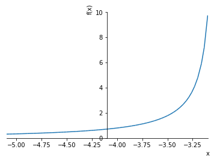

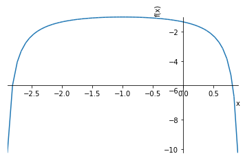

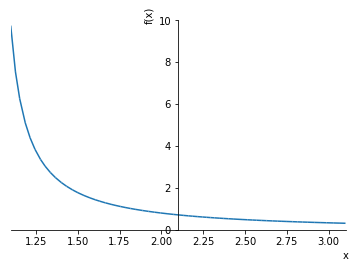

```python
plot(y, (x, -5.1, -3.1)); plot(y, (x, -2.9, 0.9)); plot(y, (x, 1.1, 3.1));
```

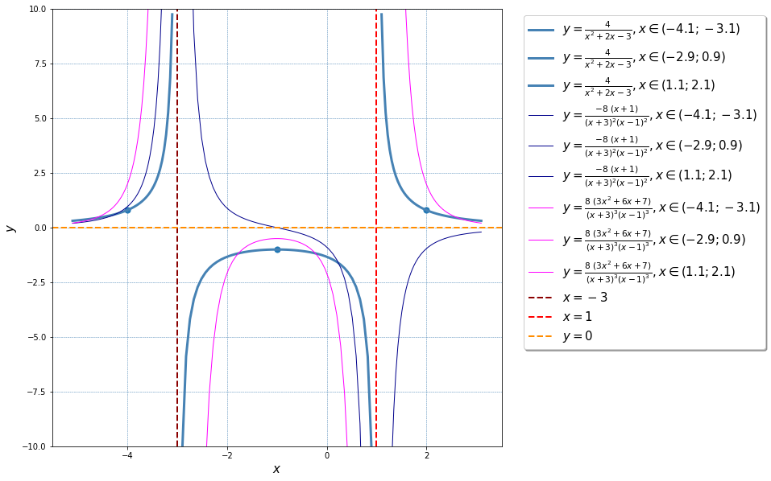

```python
x1 = numpy.linspace(-5.1, -3.1); x2 = numpy.linspace(-2.9, 0.9); x3 = numpy.linspace(1.1, 3.1)
y = lambda x: 4 / (x ** 2 + 2 * x - 3)
dy = lambda x: -8 * (x + 1) / (x ** 2 + 2 * x - 3) ** 2
d2y = lambda x: 8 * (3 * x ** 2 + 6 * x + 7) / (x ** 2 + 2 * x - 3) ** 3

plt.figure(figsize=(10,10)) ; plt.grid(c='steelblue',ls='--',lw=0.5)
plt.plot(x1, y(x1), c='steelblue', lw=3, label=r'$y = \frac{4}{x^2 + 2 x - 3}, x \in (-4.1; -3.1)$')
plt.plot(x2, y(x2), c='steelblue', lw=3, label=r'$y = \frac{4}{x^2 + 2 x - 3}, x \in (-2.9; 0.9)$')
plt.plot(x3, y(x3), c='steelblue', lw=3, label=r'$y = \frac{4}{x^2 + 2 x - 3}, x \in (1.1; 2.1)$')

plt.plot(x1, dy(x1), c='darkblue', lw=1,
         label=r'$y =  \frac{ - 8 \ (x + 1)}{(x + 3)^2 (x - 1)^2}, x \in (-4.1; -3.1)$')
plt.plot(x2, dy(x2), c='darkblue', lw=1,
         label=r'$y =  \frac{ - 8 \ (x + 1)}{(x + 3)^2 (x - 1)^2} , x \in (-2.9; 0.9)$')
plt.plot(x3, dy(x3), c='darkblue', lw=1,
         label=r'$y =  \frac{ - 8 \ (x + 1)}{(x + 3)^2 (x - 1)^2} , x \in (1.1; 2.1)$')

plt.plot(x1, d2y(x1), c='magenta', lw=1,
         label=r'$y =  \frac{ 8 \ (3 x^2 + 6x + 7)}{(x + 3)^3 (x - 1)^3}, x \in (-4.1; -3.1)$')
plt.plot(x2, d2y(x2), c='magenta', lw=1,
         label=r'$y =  \frac{ 8 \ (3 x^2 + 6x + 7)}{(x + 3)^3 (x - 1)^3} , x \in (-2.9; 0.9)$')
plt.plot(x3, d2y(x3), c='magenta', lw=1,
         label=r'$y =  \frac{ 8 \ (3 x^2 + 6x + 7)}{(x + 3)^3 (x - 1)^3} , x \in (1.1; 2.1)$')

plt.axvline(-3, c='darkred',ls='--',lw=2, label=r'$x = - 3$')
plt.axvline(1, c='red',ls='--',lw=2, label=r'$x = 1$')
plt.axhline(0, c='darkorange',ls='--',lw=2, label=r'$y = 0$')

plt.scatter([-4, -1, 2], [y(-4), y(-1), y(2)], s=50)

plt.xlabel(r'$x$', fontsize=15); plt.ylabel(r'$y$', fontsize=15); plt.ylim(-10, 10)
plt.legend(fontsize=15, shadow=True, bbox_to_anchor=(1.6,1.0));
```

## Типовой расчет №15

Провести полное исследование функции и построить ее график.

$\large{\displaystyle{ y = (2 + x) \ e^{x - 4} }}$

```python
x = Symbol('x')
y = (2 + x) * E ** (x - 4)
```

## Решение

1) Найдем область определения функции и точки разрыва.

$\large{\displaystyle{ \forall x \in \mathbb{R}: \exists y(x); D(y)= (-\infty; +\infty) }}$

Функция определена и непрерывна для всех значений аргумента из множества действительных чисел.

Точек разрыва нет.

2) Вычислим односторонние пределы функции

- в граничных точках области определения,
- в точках разрыва.

Найдем вертикальные асимптоты.

$\large{\displaystyle{ \lim_{ x \to +\infty} (2 + x) \ e^{x - 4} = \lim_{ x \to +\infty} (2 + x) \lim_{ x \to +\infty} e^{x - 4} = +\infty \cdot +\infty = +\infty }}$

$\large{\displaystyle{ \lim_{ x \to -\infty} (2 + x) \ e^{x - 4} = \lim_{ x \to -\infty} (2 + x) \lim_{ x \to -\infty} e^{x - 4} = [-\infty \cdot 0] }}$

Для раскрытия неопределенности используем правило Лопиталя.

$\large{\displaystyle{ \lim_{ x \to -\infty} (2 + x) \ e^{x - 4} = \lim_{ x \to -\infty} \frac{x + 2}{e^{4 - x}} = \lim_{ x \to -\infty} \frac{(x + 2)'}{(e^{4 - x}) '} = }}$

$\large{\displaystyle{ = \lim_{ x \to -\infty} \frac{1}{ -e^{4 - x}} = 0}}$

Точек разрыва нет, значит и вертикальных асимптот нет.

```python
limit(y, x, -oo), limit(y, x, +oo)
```

$$\left ( 0, \quad \infty\right )$$

3) Проверим, является ли функция четной, нечетной, периодической.

$\large{\displaystyle{ y (-x) = (2 + (-x)) \ e^{-x - 4} = \frac{2 - x}{e^{x + 4}} }}$

$\large{\displaystyle{ y (-x) \neq y(x) \land y (-x) \neq -y(x) }}$

Функция не является четной или нечетной.

Обозначим $ t \neq 0$ предполагаемый период функции.

$\large{\displaystyle{y(x + t) = y(x) \iff (2 + x + t) \ e^{x + t - 4} = (2 + x) \ e^{x - 4} \iff }}$

$\large{\displaystyle{\iff ( 2 + x + t) \ e^{x + t - 4} - (2 + x) \ e^{x - 4} = 0 \iff }}$

$\large{\displaystyle{ \iff (t \ e^t + x \ e^t - x + 2 \ e^t - 2) \ e^{x-4} = 0 \iff }}$

$\large{\displaystyle{\iff t \ e^t + x \ e^t - x + 2 \ e^t - 2 = 0 \iff}}$

$\large{\displaystyle{ \iff e^t \ (t + x + 2 ) = x + 2 \iff e^t = \frac{x + 2}{t + x + 2} }}$

$\large{\displaystyle{ t \neq const \land t = t(x) }}$

Функция не является периодической.

4) Найдем точки пересечения графика функции с осями координат.

$\large{\displaystyle{x = 0 \implies y = \frac{2}{e^4} \approx 0.04 }}$

$\large{\displaystyle{y = 0 \iff (2 + x) \ e^{x - 4} = 0 \iff x + 2 = 0 \iff x = -2 }}$

График функции пересекает ось $Oy$ в точке $(0; \frac{2}{e^4})$ и пересекает ось $Ox$ в точке $(-2; 0)$ .

```python
(2 + x) * E ** (x - 4) == (2 + (-x)) * E ** ((-x) - 4)
```

```
False
```

```python
-(2 + x) * E ** (x - 4) == (2 + (-x)) * E ** ((-x) - 4)
```

```
False
```

```python
t = Symbol(' t')
solve(((2 + x + t) * E ** (x + t - 4) - (2 + x) * E ** (x - 4))/ E ** (x - 4), t)
```

$$\left [ - x + \operatorname{LambertW}{\left (\left(x + 2\right) e^{x + 2} \right )} - 2\right ]$$

```python
y.evalf(subs={x:0})
```

$$0.0366312777774684$$

```python
solve((2 + x) * E ** (x - 4), x)
```

$$\left [ -2, \quad \tilde{\infty}\right ]$$

5) Найдем наклонные асимпоты графика функции.

$\large{\displaystyle{\lim_{ x \to +\infty} \frac{(2 + x) \ e^{x - 4}}{x} = \lim_{ x \to +\infty} \frac{2 + x}{x} \lim_{ x \to +\infty} e^{x - 4} = }}$

$\large{\displaystyle{= \lim_{ x \to +\infty} \bigg(\frac{2}{x} + 1\bigg) \lim_{ x \to +\infty} e^{x - 4} = 1 \cdot +\infty = +\infty }}$

$\large{\displaystyle{\lim_{ x \to -\infty} \frac{(2 + x) \ e^{x - 4}}{x} = \lim_{ x \to -\infty} \frac{2 + x}{x} \lim_{ x \to -\infty} e^{x - 4} = }}$

$\large{\displaystyle{= \lim_{ x \to -\infty} \bigg(\frac{2}{x} + 1\bigg) \lim_{ x \to -\infty} e^{x - 4} = 1 \cdot 0 = 0 }}$

6) Вычислим первую производную. Найдем точки локального экстремума и промежутки монотонности.

$\large{\displaystyle{y ' = ((2 + x) \ e^{x - 4}) ' = (2 + x)' \ e^{x - 4} + (2 + x) \ (e^{x - 4})' = e^{x - 4} + (2 + x) \ e^{x - 4} }}$

$\large{\displaystyle{y ' = (3 + x) \ e^{x - 4} }}$

Производная определена и непрерывна для всех значений аргумента из множества действительных чисел.

Точками локального экстремума могут быть только стационарные точки, для которых $y ' = 0$.

$\large{\displaystyle{y ' = 0 \iff (3 + x) \ e^{x - 4} = 0 \iff x + 3 = 0 \iff x = -3 }}$

$\large{\displaystyle{y (-3) = (2 - 3) \ e^{-3 - 4} = -\frac{1}{e^7} \approx -0.001}}$

Промежутки монотонности:

| $x$ | $(-\infty; -3)$ | $-3$ | $(-3; +\infty)$ |
| --- | --- | --- | --- |
| $y ' (x)$ | $-$ | $0$ | $+$ |
| $y (x)$ | $\searrow$ | $-\frac{1}{e^7}$ | $\nearrow$ |

$(-\infty; -3)$ - функция убывает.

$(-3; +\infty)$ - функция возрастает.

```python
limit((2 + x) * E ** (x - 4) / x, x, oo), limit((2 + x) * E ** (x - 4) / x, x, -oo)
```

$$\left ( \infty, \quad 0\right )$$

```python
simplify(diff(y, x))
```

$$\left(x + 3\right) e^{x - 4}$$

```python
solve(diff(y, x), x)
```

$$\left [ -3\right ]$$

```python
y.evalf(subs={x:-3})
```

$$-0.000911881965554516$$

```python
solve(diff(y, x) > 0, x), solve(diff(y, x) < 0, x)
```

$$\left ( -3 < x \wedge x < \infty, \quad -\infty < x \wedge x < -3\right )$$

7) Вычислим вторую производную. Найдем точки перегиба графика функции и промежутки выпуклости.

$\large{\displaystyle{y '' = ((3 + x) \ e^{x - 4}) ' = (3 + x)' \ e^{x - 4} + (3 + x) \ (e^{x - 4})' = e^{x - 4} + (3 + x) \ e^{x - 4} }}$

$\large{\displaystyle{y '' = (4 + x) \ e^{x - 4} }}$

Вторая производная определена и непрерывна для всех значений аргумента из множества действительных чисел.

Точками перегиба могут быть только те, для которых $y '' = 0$.

$\large{\displaystyle{y '' = 0 \iff (4 + x) \ e^{x - 4} = 0 \iff x + 4 = 0 \iff x = -4 }}$

$\large{\displaystyle{y (-4) = (2 - 4) \ e^{-4 - 4} = -\frac{2}{e^8} \approx -0.0007}}$

Промежутки выпуклости:

| $x$ | $(-\infty; -4)$ | $-4$ | $(-4; +\infty)$ |
| --- | --- | --- | --- |
| $y '' (x)$ | $-$ | 0 | $+$ |
| $y (x)$ | $\cap$ | $ -\frac{2}{e^8}$ | $\cup$ |

Функция имеет одну точку перегиба $(-4; -\frac{2}{e^8})$.

$(-4; +\infty)$ - график функции является выпуклым вниз.

$(-\infty; -4)$ - график функции является выпуклым вверх.

```python
simplify(diff(diff(y,x), x))
```

$$\left(x + 4\right) e^{x - 4}$$

```python
solve(diff(diff(y,x), x), x)
```

$$\left [ -4\right ]$$

```python
y.evalf(subs={x:-4})
```

$$-0.000670925255805024$$

```python
solve(diff(diff(y, x), x) > 0, x), solve(diff(diff(y, x), x) < 0, x)
```

$$\left ( -4 < x \wedge x < \infty, \quad -\infty < x \wedge x < -4\right )$$

8) Построим график функции.

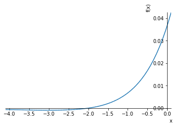

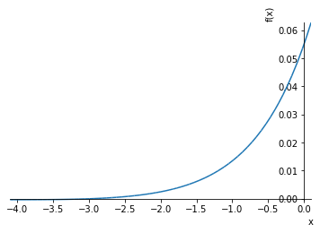

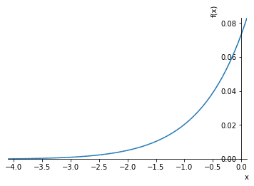

```python
plot(y, (x, -4.1, 0.1)); plot(diff(y,x), (x, -4.1, 0.1)); plot(diff(diff(y,x), x), (x, -4.1, 0.1));
```

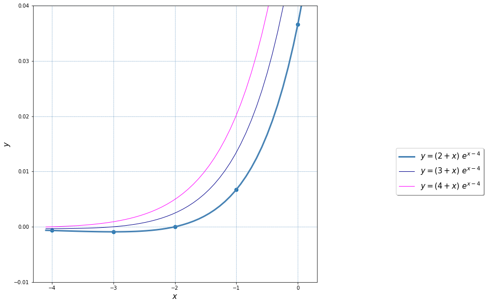

```python
x = numpy.linspace(-4.1, 0.1)
y = lambda x: (2 + x) * numpy.exp(x - 4)
dy = lambda x: (3 + x) * numpy.exp(x - 4)
d2y = lambda x: (4 + x) * numpy.exp(x - 4)

plt.figure(figsize=(10,10)) ; plt.grid(c='steelblue',ls='--',lw=0.5)

plt.plot(x, y(x), c='steelblue', lw=3, label=r'$ y = (2 + x) \ e^{x - 4}$')
plt.plot(x, dy(x), c='darkblue', lw=1, label=r'$ y = (3 + x) \ e^{x - 4}$')
plt.plot(x, d2y(x), c='magenta', lw=1, label=r'$ y = (4 + x) \ e^{x - 4}$')

plt.scatter([-4, -3, -2, -1, 0], [y(-4), y(-3), y(-2), y(-1), y(0)], s=50)

plt.xlabel(r'$x$', fontsize=15); plt.ylabel(r'$y$', fontsize=15); plt.ylim(-0.01, 0.04)
plt.legend(fontsize=15, shadow=True, bbox_to_anchor=(1.6,0.5));
```